# Week7-5 Network

Kyu Cho

July 17, 2015

# Introduction

The cliche goes that the world is an increasingly interconnected place, and the connections between different entities are often best represented with a graph. Graphs are comprised of vertices (also often called “nodes”) and edges connecting those nodes. In this assignment, we will learn how to visualize networks using the igraph package in R.

For this assignment, we will visualize social networking data using anonymized data from Facebook; this data was originally curated in a recent paper about computing social circles in social networks. In our visualizations, the vertices in our network will represent Facebook users and the edges will represent these users being Facebook friends with each other.

# Variables

The first file we will use, edges.csv, contains variables V1 and V2, which label the endpoints of edges in our network. Each row represents a pair of users in our graph who are Facebook friends. For a pair of friends A and B, edges.csv will only contain a single row – the smaller identifier will be listed first in this row. From this row, we will know that A is friends with B and B is friends with A.

- id: A unique identifier for this user; this is the value that appears in the rows of edges.csv
- gender: An identifier for the gender of a user taking the values A and B. Because the data is anonymized, we don’t know which value refers to males and which value refers to females.
- school: An identifier for the school the user attended taking the values A and AB (users with AB attended school A as well as another school B). Because the data is anonymized, we don’t know the schools represented by A and B.
- locale: An identifier for the locale of the user taking the values A and B. Because the data is anonymized, we don’t know which value refers to what locale. The second file, users.csv, contains information about the Facebook users, who are the vertices in our network. This file contains the following variables:

```r
library(igraph)
setwd("D:/Google Drive/College/4-The Analytics Edge/data7")
edges = read.csv("edges.csv")
users = read.csv("users.csv")
```

```r
str(edges)
```

```
## 'data.frame':    146 obs. of  2 variables:
##  $ V1: int  4019 4023 4023 4027 3988 3982 3994 3998 3993 3982 ...
##  $ V2: int  4026 4031 4030 4032 4021 3986 3998 3999 3995 4021 ...
```

```r
str(users)
```

```
## 'data.frame':    59 obs. of  4 variables:
##  $ id    : int  3981 3982 3983 3984 3985 3986 3987 3988 3989 3990 ...
##  $ gender: Factor w/ 3 levels "","A","B": 2 3 3 3 3 3 2 3 3 2 ...
##  $ school: Factor w/ 3 levels "","A","AB": 2 1 1 1 1 2 1 1 2 1 ...
##  $ locale: Factor w/ 3 levels "","A","B": 3 3 3 3 3 3 2 3 3 2 ...
```

```r
# Out of all the students who listed a school, what was the most common locale?
table(users$locale, users$school)
```

```
##
##         A AB
##      3  0  0
##   A  6  0  0
##   B 31 17  2
```

```r
# Is it possible that either school A or B is an all-girls or all-boys school? - No
table(users$gender, users$school)
```

```
##
##         A AB
##      1  1  0
##   A 11  3  1
##   B 28 13  1
```

# CREATING A NETWORK

```r
g = graph.data.frame(edges, FALSE, users)
```

From ?graph.data.frame, we can see that the function expects the first two columns of parameter d to specify the edges in the graph – our edges object fits this description.  
Our edges are undirected – if A is a Facebook friend of B then B is a Facebook friend of A. Therefore, we set the directed parameter to FALSE.  
The vertices parameter expects a data frame where the first column is a vertex id and the remaining columns are properties of vertices in our graph. This is the case with our users data frame.

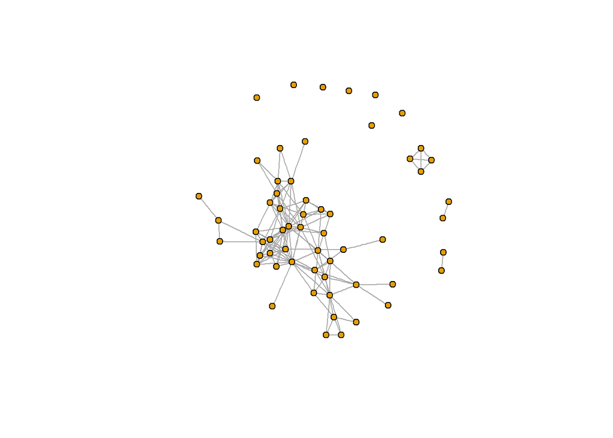

```r
plot(g, vertex.size=5, vertex.label=NA)
```

```r
# How many users are friends with 10 or more other Facebook users in this network?
sort(degree(g))
```

```
## 3984 4008 4010 4015 4022 4024 4035 3983 3987 4001 4006 4012 4028 4029 4032
##    0    0    0    0    0    0    0    1    1    1    1    1    1    1    1
## 4034 4036 3991 3992 4005 4033 3990  594 3996 3999 4007 4011 4016 4025 4037
##    1    1    2    2    2    2    3    3    3    3    3    3    3    3    3
## 4003 3985 3989 3993 4013 3988 4002 4018 4027 3981 4019 4020 3986 3995 4000
##    4    5    5    5    5    6    6    6    6    7    7    7    8    8    8
## 4017 4026 4038 4004 4009 3994 3997 4021 4031 4014 3982 3998 4023 4030
##    8    8    8    9    9   10   10   10   10   11   13   13   17   18
```

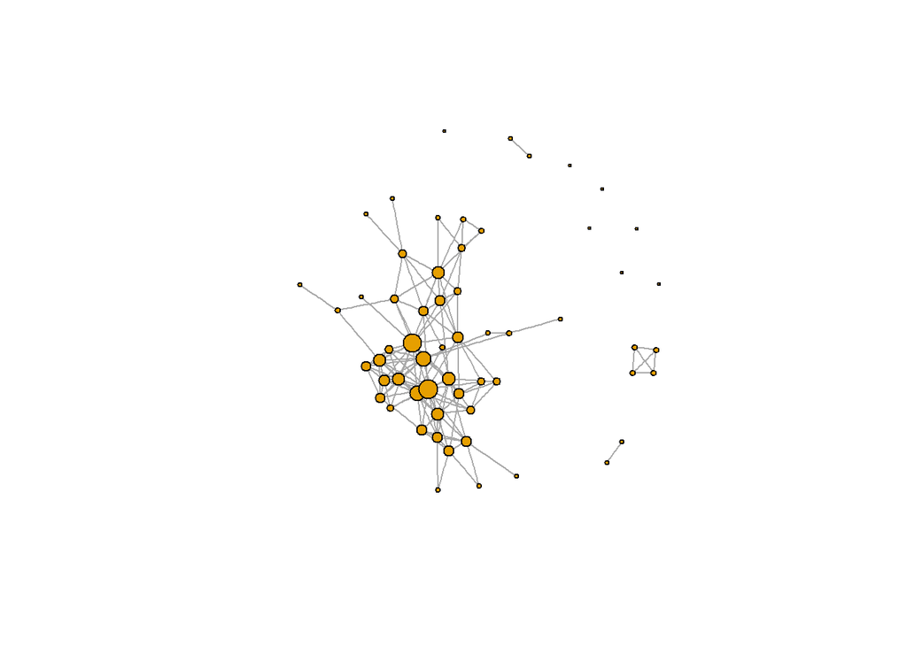

```r
# Make people with more friends to be more appeared.
V(g)$size = degree(g)/2+2
plot(g, vertex.label=NA)
```

```r
# What is the largest size we assigned to any node in our graph?
table(degree(g)/2+2)
```

```
##
##    2  2.5    3  3.5    4  4.5    5  5.5    6  6.5    7  7.5  8.5 10.5   11
##    7   10    4    9    1    4    4    3    6    2    4    1    2    1    1
```

# COLORING VERTICES

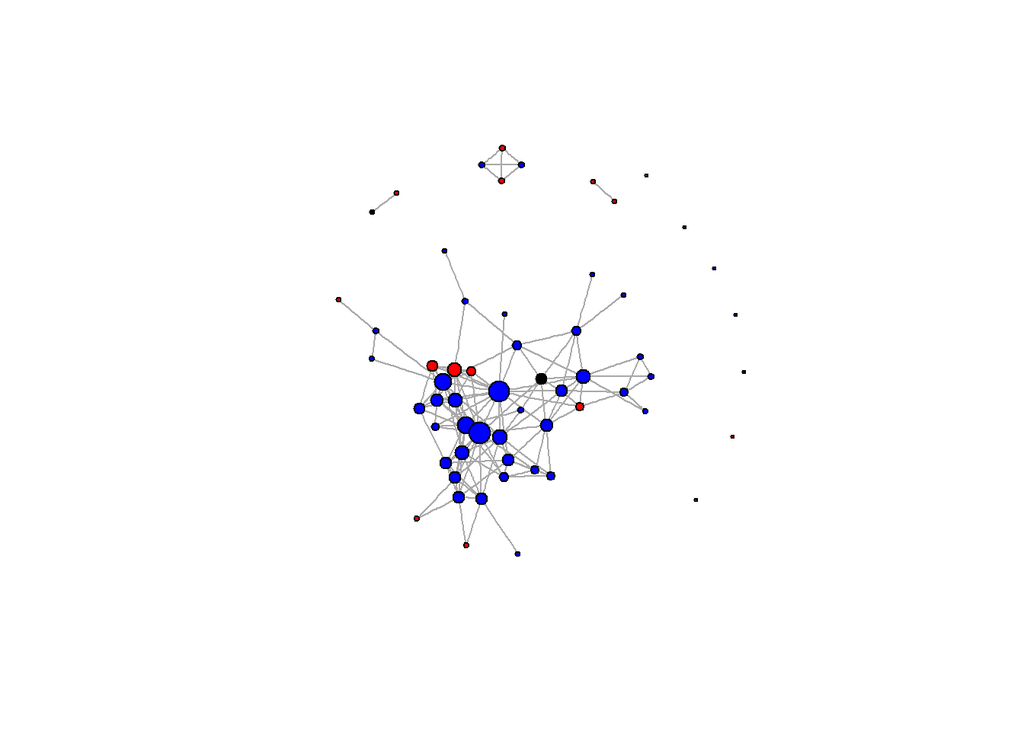

```r
# What is the gender of the users with the highest degree in the graph?
V(g)$color = "black"
V(g)$color[V(g)$gender == "A"] = "red"
V(g)$color[V(g)$gender == "B"] = "blue"
plot(g, vertex.label=NA)
```

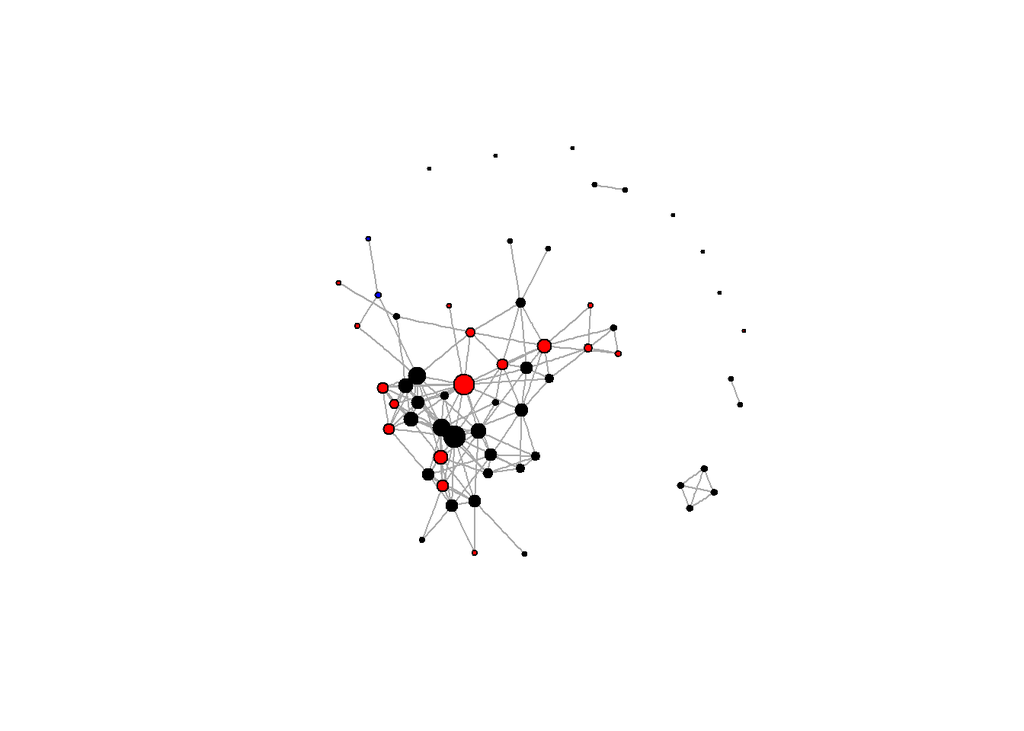

```r
# Color the vertices based on the school that each user in our network attended.
V(g)$color = "black"
V(g)$color[V(g)$school == "A"] = "red"
V(g)$color[V(g)$school == "AB"] = "blue"
plot(g, vertex.label=NA)
```

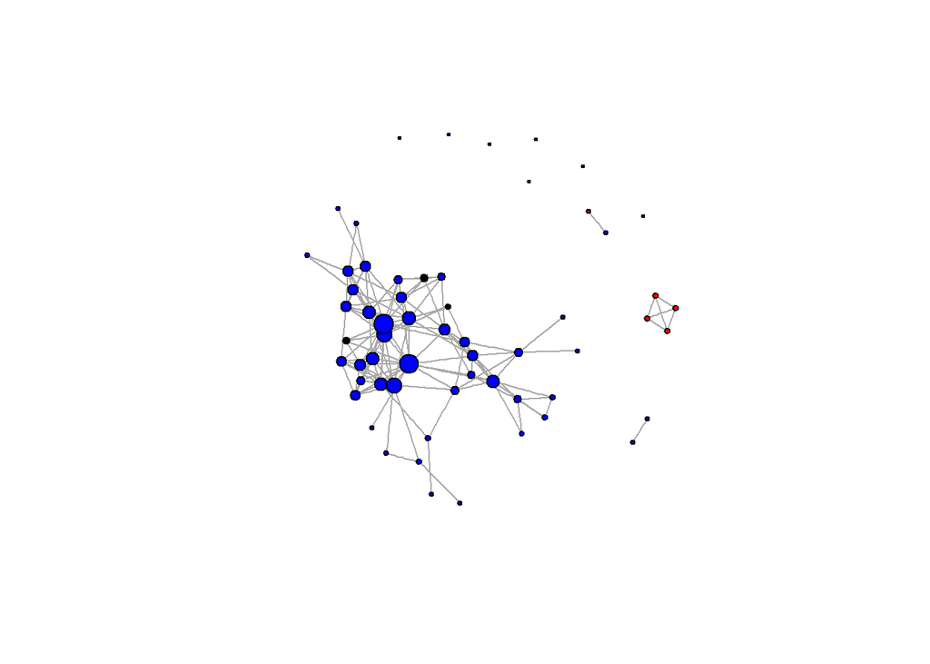

```r
# Color the vertices based on the locale of the user.
V(g)$color = "black"
V(g)$color[V(g)$locale == "A"] = "red"
V(g)$color[V(g)$locale == "B"] = "blue"
plot(g, vertex.label=NA)
```